# Vertex Nomination via Seeded Graph Matching

Kemeng Zhang

2018-05-11

```r
# Dependencies.
suppressMessages(require(graphstats))
suppressMessages(require(igraph))
suppressMessages(require(ggplot2))
```

# Background

Given two networks that we believe to have some correspondence, we may want to match the nodes of one network to those of the other; that is, we want to find the bijection between the vertex sets that minimizes the number of edge disagreements across the graph. An edge disagreement occurs when two vertices are adjacent on in one graph but their corresponding vertices in the other are not.

Herein we present a principled methodology appropriate for situations in which the networks are too large for brute-force graph matching. Our methodology identifies vertices in a local neighborhood of the vertices of interest in the first network that have verifiable corresponding vertices in the second network.

# Example 1: A Known Correspondence

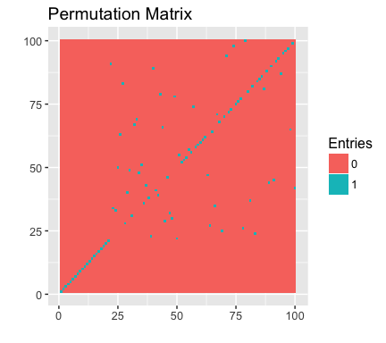

```r
# Number of seeds, total nubmer of vertices, and edge probability.
m <- 20
n <- 100
p <- 0.5
set.seed(123)
# Sample matrix A, and permute to .
A <- matrix(as_adj(sample_sbm(n, as.matrix(p), n)), nrow = n)
permutation = sample(n-m) + m
B <- A[c(1:m, permutation),]

# P is the permutation matrix that will turn match B to A.

# Unordered call.
seeds <- matrix(cbind(1:m, 1:m), nrow = m)
P <- sgm(A, B, seeds)

# Display.
gs.plot.plot_matrix(P, title="Permutation Matrix", legend.name="Entries", ffactor = TRUE)
```

By applying the returned matrix to B, we can assess the quality of the matching.

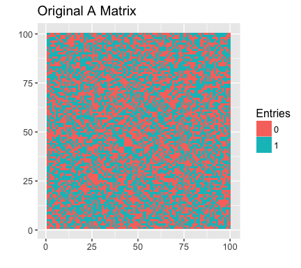

```r
# Apply permutation matrix.
B_matched <- P %*% B %*% t(P)

# Visualize matched graphs.
gs.plot.plot_matrix(A, title="Original A Matrix", legend.name="Entries", ffactor = TRUE)
```

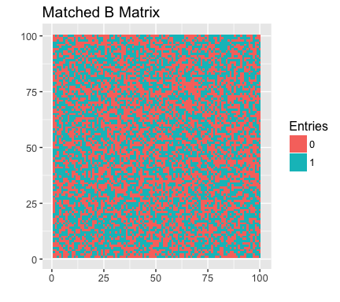

```r
gs.plot.plot_matrix(B_matched, title="Matched B Matrix", legend.name="Entries", ffactor = TRUE)
```

The overall connectivity of A is very closely recovered.

# Example 2: r-Correlated SBM

Here, we sample (A, B) from an r-Correlated SBM via a random dot-product graph, permute the matrix like before, and observe the results of Seeded Graph Matching.

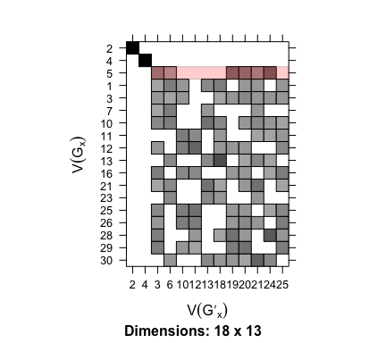

```r
for (i in 1:2) {
  s <- 4 # number of seeds to be used for SGM
  h <- ell <- 1 # max walk for finding neighborhoods

  # parameters for SGM
  R <- 100     # repeat SGM R times to get averaged P matrix
  gamma <- 0.1 # number of iterations for the Frank-Wolfe algorithm

  m <- 5  # |J| = junk on G1
  n <- 20 # |W| = shared vertices on G1, not including x and S
  mp <- 0 # |J'| = junk on G2
  d <- 5  # for RDPG, dimension of the random vectors
  corr <- 0.5 # for correlated graphs
  nV1 <- 1+s+n+m # number of vertices in graph 1
  nV2 <- 1+s+n+mp # number of vertices in graph 2
  lpvs <- sample_sphere_surface(dim=d, n=nV1) / 1.5 # random vectors for RDPG
  gg <- rdpg.sample.correlated(t(lpvs),corr)
  g1 <- gg[[1]];
  g2 <- gg[[2]];
  g2 <- delete_vertices(g2,v=(nV2+1):nV1); # remove m vertices from G' to make |V(G)| != |V(G')|
  W <- intersect(V(g1),V(g2)) # shared vertices
  # Randomly select x and S from W, the shared vertices
  x <- sample(W,1)
  W <- setdiff(W,x) # exclude x from W
  maxseed <- min(length(W),s)
  S <- sort(sample(W,maxseed))
  seeds <- matrix(cbind(1:maxseed, S), nrow = maxseed)
  # Determine Sx and C'x, then do SGM
  NBDS <- vnsgm(x,seeds,g1,g2,h,ell,R,gamma,plotF = TRUE)
}
```

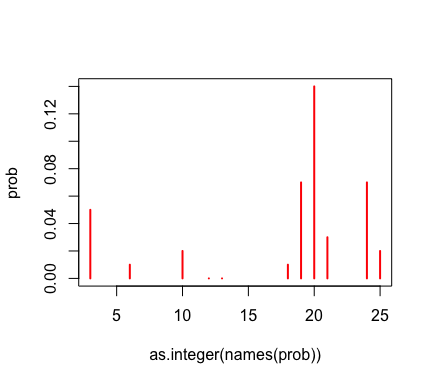

Rank of matching probability for candidates

| V3 | V6 | V10 | V12 | V13 | V18 | V19 | V20 | V21 | V24 | V25 |
| --- | --- | --- | --- | --- | --- | --- | --- | --- | --- | --- |
| 4 | 8.5 | 6.5 | 10.5 | 10.5 | 8.5 | 2.5 | 1 | 5 | 2.5 | 6.5 |

```r
# Determine x' amongst the candidates based on the matching probability from SGM
Sx <- NBDS$Sx
x <- NBDS$labelsGxp[length(Sx)+1]
x.ind <- which(NBDS$labelsGx==x)
Cxp <- match(NBDS$Cxp,NBDS$labelsGxp)

if (NBDS$case=="possible") {
    prob <- NBDS$P[x.ind,Cxp]
    names(prob) <- NBDS$labelsGxp[Cxp]
    x.prob <- prob[which.max(prob)]
    vhatstar <- as.integer(names(x.prob))
    rank.prob <- rank(-prob,ties.method = "average")
    plot(as.integer(names(prob)), prob, type="h",col=2, lwd=2)
    rank.prob <- matrix(rank.prob,nrow=1); colnames(rank.prob) <- paste0("V",names(prob))
    knitr::kable(rank.prob,caption="Rank of matching probability for candidates")
}
```